# De Benedictis project_

Alberto De Benedictis

```r
library(limma)
library(Seurat)
library(dplyr)
```

Question 3:

Load your data into Seurat, using the same “filtering” thresholds of the vignette we used. How many genes and how many cells compose the initial count table you will work on? Is the number of cells different from the one you found in the Excel table for your dataset?

```r
load("SRA667466_SRS3059974.sparse.RData")

#removeing the ENSEMBL gene version
row.names(sm) <- gsub('\\_ENS.*', '', row.names(sm))
row.names(sm) <- make.unique(row.names(sm))
# loading the surat obj removing what genes and cells that are too few.
socr <- CreateSeuratObject(counts = sm, project = "medobl", min.cells = 3, min.features = 200)
socr
```

```
## An object of class Seurat
## 22749 features across 6469 samples within 1 assay
## Active assay: RNA (22749 features, 0 variable features)
##  1 layer present: counts
```

Question 4:

Compute the % of mitochondrial RNA in each cell as in the Seurat vignette. For doing this you have to “clean” the row names removing the “ENSG…” identifier and keeping only the gene symbol. Produce the violin plots of “feature RNA”, “count RNA”, and “percent MT” as in the Seurat vignette and insert the Figure here.

```r
socr[["percent.mt"]] <- PercentageFeatureSet(socr, pattern = "^mt-")
head(socr@meta.data, 5)
```

```
##                  orig.ident nCount_RNA nFeature_RNA percent.mt
## AAACCTGAGACTTGAA     medobl       7572         2662   2.839408
## AAACCTGAGAGCAATT     medobl       1315          881   4.410646
## AAACCTGAGCACAGGT     medobl       2869         1294   3.311258
## AAACCTGAGCGTGTCC     medobl       1299          735   8.622017
## AAACCTGAGGTGGGTT     medobl       3321         1446   3.312255
```

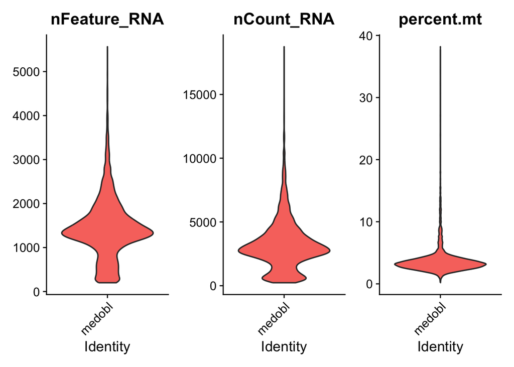

```r
VlnPlot(socr, features = c("nFeature_RNA", "nCount_RNA", "percent.mt"), ncol = 3, pt.size=0)
```

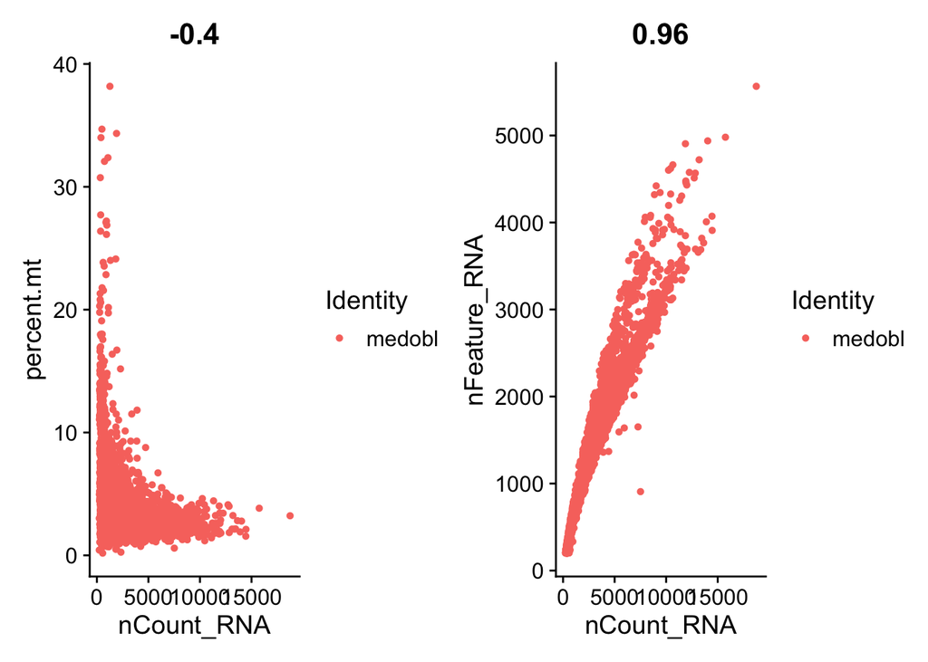

```r
plot1 <- FeatureScatter(socr, feature1 = "nCount_RNA", feature2 = "percent.mt")
plot2 <- FeatureScatter(socr, feature1 = "nCount_RNA", feature2 = "nFeature_RNA")
plot1 + plot2
```

Question 5:

Doublets/empty drops/low quality cell removal. Starting from the result of the previous step, do you think that the parameters used in the vignette are ok (i.e. minimum/maximum number of expressed genes, % of MT RNA), or you think it is better to change some of them and why? After the removal of the “low quality cells”, is the number of cells left higher or lower than the one reported in the Excel table for your dataset?

```r
socr <- subset(socr, subset = nFeature_RNA > 200 & nFeature_RNA < 2500 & percent.mt < 5)
socr
```

```
## An object of class Seurat
## 22749 features across 5289 samples within 1 assay
## Active assay: RNA (22749 features, 0 variable features)
##  1 layer present: counts
```

Question 6:

After selection of the 2,000 most variable genes, list here the “top 10” most variable ones and build a plot like the one found in the Seurat vignette highlighting them in red.

```r
socr_norm <- NormalizeData(socr, normalization.method = "LogNormalize", scale.factor = 10000)
```

```
## Normalizing layer: counts
```

```r
socr_norm <- FindVariableFeatures(socr_norm, selection.method = "vst", nfeatures = 2000)
```

```
## Finding variable features for layer counts
```

```r
top10 <- head(VariableFeatures(socr_norm), 10)
top10
```

```
##  [1] "Meg3"         "Rgs5"         "Bsg"          "Cst3"         "Cldn5"
##  [6] "Flt1"         "Marcks"       "Gfap"         "Apoe"         "RP23-47H16.3"
```

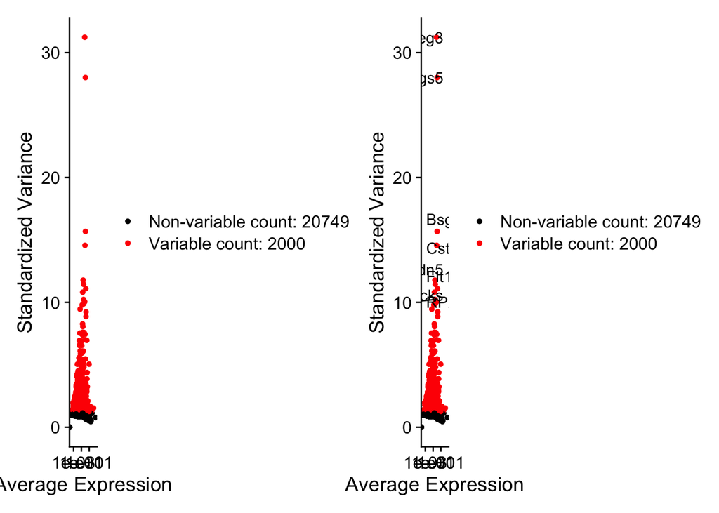

```r
# plot variable features with and without labels
plot1 <- VariableFeaturePlot(socr_norm)
plot2 <- LabelPoints(plot = plot1, points = top10, repel = TRUE, xnudge = 0, ynudge = 0)
plot1 + plot2
```

Question 7:

After checking for cell cycle phase, do you think it necessary to scale data “regressing out” the cell cycle? A figure explaining your answer might be useful.

```r
s.genes <- cc.genes$s.genes
g2m.genes <- cc.genes$g2m.genes

# Regressing out the mitochondrial genes but NOT the cell cycle:

socr <- ScaleData(socr_norm, vars.to.regress = "percent.mt")
socr <- CellCycleScoring(socr, s.features = s.genes, g2m.features = g2m.genes, set.ident = TRUE)
head(socr[[]])
```

```
##                  orig.ident nCount_RNA nFeature_RNA percent.mt     S.Score
## AAACCTGAGAGCAATT     medobl       1315          881   4.410646 -0.05158405
## AAACCTGAGCACAGGT     medobl       2869         1294   3.311258  0.01791460
## AAACCTGAGGTGGGTT     medobl       3321         1446   3.312255 -0.02390872
## AAACCTGGTCATATCG     medobl       1734          862   3.517878 -0.02183827
## AAACCTGGTGGGTATG     medobl       2983         1327   3.721086  0.02197942
## AAACCTGGTGTTCGAT     medobl       5726         2158   2.811736  0.02215886
##                    G2M.Score Phase old.ident
## AAACCTGAGAGCAATT  0.01349522   G2M    medobl
## AAACCTGAGCACAGGT  0.05628562   G2M    medobl
## AAACCTGAGGTGGGTT  0.03171557   G2M    medobl
## AAACCTGGTCATATCG -0.02603984    G1    medobl
## AAACCTGGTGGGTATG  0.02329926   G2M    medobl
## AAACCTGGTGTTCGAT  0.05433358   G2M    medobl
```

```r
socr <- RunPCA(socr, features = VariableFeatures(object = socr))
```

```
## PC_ 1
## Positive:  Flt1, Cldn5, Itm2a, Egfl7, Slco1a4, Adgrf5, Ablim1, Cd93, Ly6c1, Col4a2
##     Adgrl4, Rgs5, Cd34, Fn1, Eng, Ptprb, Itga1, Id1, Spock2, Kdr
##     Fam101b, Ebf1, Abcb1a, Col4a1, Slco1c1, Klf2, Igfbp7, Podxl, Ly6e, Slfn5
## Negative:  Cnp, Cldn11, Mobp, Mbp, Mog, Mag, Hmgcs1, Tspan2, Enpp2, Mal
##     Dpysl2, Fth1, Olig1, Ank3, Arpc1a, Fez1, Sh3gl3, Tsc22d4, Sema4d, Marcksl1
##     Nfasc, Etv1, Sirt2, Gsn, Trf, Gng12, Kndc1, Grb14, Hmgcr, Enpp6
## PC_ 2
## Positive:  Mal, Fth1, Mobp, Mog, Gng11, Cldn11, Etv1, Tspan2, Cnp, Enpp2
##     Ptn, Mag, Glul, Hapln2, Trf, Klf13, Mbp, Slc6a6, Hmgcs1, Apod
##     Grb14, Anln, Flt1, Gsn, Cldn5, Slco1a4, Adgrl4, Cd93, Ly6c1, Adgrf5
## Negative:  Chchd10, Gpm6a, Mt3, Slc38a1, Id4, Meg3, Rtn1, Gja1, Aqp4, Nnat
##     Nsg2, Ntrk2, Gpr37l1, Tmem47, Atp1b2, Fut9, Ptprz1, Clu, Mlc1, Marcks
##     Gabrb1, Lsamp, Sox9, Celf4, Bcan, Nrxn1, Aldoc, RP23-168E14.7, Ednrb, Slc4a4
## PC_ 3
## Positive:  RP23-47H16.3, RP23-95H5.1, Gpr17, Tcf7l2, Kank1, Marcks, Rras2, Nfasc, Parvb, Cnksr3
##     Slc1a1, Rims2, Frmd4a, Tmem2, Fyn, Col9a3, Prom1, Itpr2, AC163993.2, Pcdh7
##     RP23-416H10.8, Cntn1, Rnf122, Sirt2, Rasgef1b, Tmem163, Opcml, Sema6a, Rtn1, Sema4f
## Negative:  Fth1, Etv1, Pmp22, Hapln2, Id4, Mt3, Mal, Slc1a3, Gja1, Aqp4
##     Chchd10, Anln, Sox9, RP24-160I20.1, Apod, Tmem47, Trf, Mlc1, Apoe, Slc38a1
##     Ncs1, Clu, Glul, Slc4a4, Atp1b2, Fez1, Gng11, Rsph1, Tmsb10, Dynlrb2
## PC_ 4
## Positive:  Gja1, Aqp4, Sox9, Mlc1, Nnat, RP24-160I20.1, Gpr37l1, Slc4a4, Id4, Apoe
##     Ednrb, Ramp1, Mt1, Rsph1, Clu, Tmem47, Dynlrb2, Bcan, Prelp, Mt3
##     Fgfr3, RP23-100C7.3, Slc6a11, Nuf2, Slc25a18, Calml4, Ezr, Atp1b2, Ntsr2, Ccdc153
## Negative:  Slc12a5, Celf4, Syp, Sncb, Snap25, Syt4, Nrsn2, Stmn2, Ndrg4, Scg2
##     Rian, Tmem130, Meg3, Nrsn1, Myt1l, Snhg11, RP23-35N23.2, Scn1a, Syt1, Scn2b
##     Grin2b, Clstn3, Elavl2, Kcnc1, Pgm2l1, Gap43, Gabra1, Napb, Bend6, Ina
## PC_ 5
## Positive:  Rsph1, RP23-100C7.3, Cd24a, Nuf2, Dnah12, Ccdc153, RP23-156N21.2, Dynlrb2, Tmem107, RP23-340G24.4
##     AL669896.1, Calml4, RP23-430H1.2, Rsph4a, Dnah9, Tm4sf1, RP23-81N4.4, Spef2, Fam183b, Dnah6
##     Hdc, Riiad1, Dnah5, Vwa3a, RP23-96I9.2, Cfap54, Fam216b, RP24-314J18.1, Meig1, Tmem212
## Negative:  Slc6a11, Ntsr2, Aldoc, Atp1b2, Slc1a2, Fgfr3, Atp1a2, RP23-168E14.7, Slc4a4, Aqp4
##     Gjb6, Gja1, Acsbg1, Acsl6, Ednrb, Agt, Sparcl1, Slc39a12, Gpm6a, Ptprz1
##     Fut9, Id2, S1pr1, Apoe, Itih3, Ncan, Cst3, Cxcl14, Gfap, Htra1
```

```r
print(socr[["pca"]], dims = 1:5, nfeatures = 5)
```

```
## PC_ 1
## Positive:  Flt1, Cldn5, Itm2a, Egfl7, Slco1a4
## Negative:  Cnp, Cldn11, Mobp, Mbp, Mog
## PC_ 2
## Positive:  Mal, Fth1, Mobp, Mog, Gng11
## Negative:  Chchd10, Gpm6a, Mt3, Slc38a1, Id4
## PC_ 3
## Positive:  RP23-47H16.3, RP23-95H5.1, Gpr17, Tcf7l2, Kank1
## Negative:  Fth1, Etv1, Pmp22, Hapln2, Id4
## PC_ 4
## Positive:  Gja1, Aqp4, Sox9, Mlc1, Nnat
## Negative:  Slc12a5, Celf4, Syp, Sncb, Snap25
## PC_ 5
## Positive:  Rsph1, RP23-100C7.3, Cd24a, Nuf2, Dnah12
## Negative:  Slc6a11, Ntsr2, Aldoc, Atp1b2, Slc1a2
```

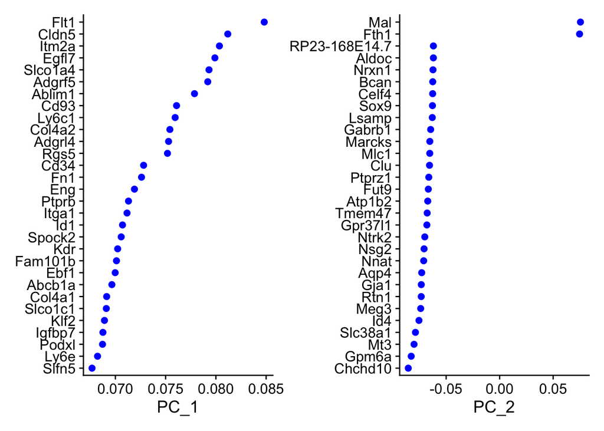

```r
VizDimLoadings(socr, dims = 1:2, reduction = "pca")
```

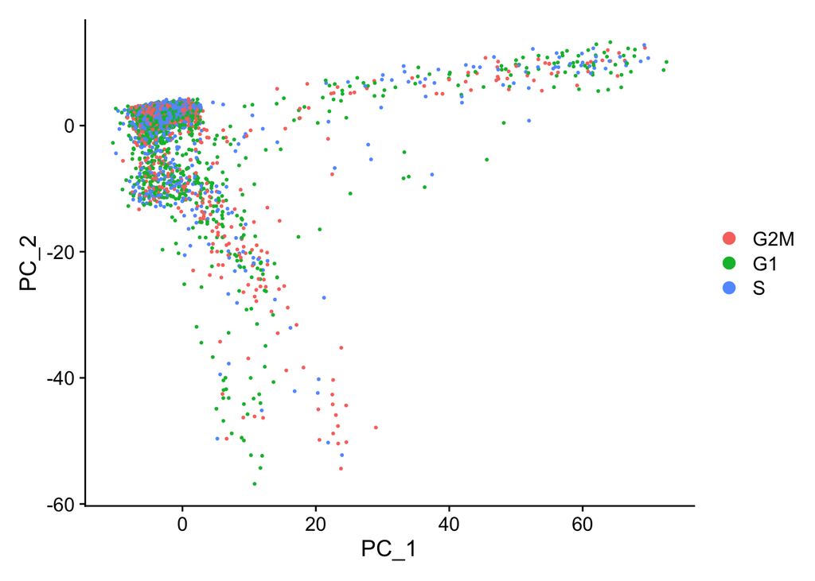

```r
DimPlot(socr, reduction = "pca")
```

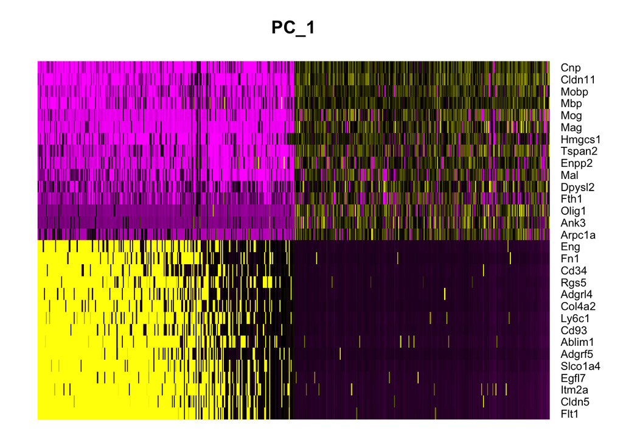

```r
DimHeatmap(socr, dims = 1, cells = 500, balanced = TRUE)
```

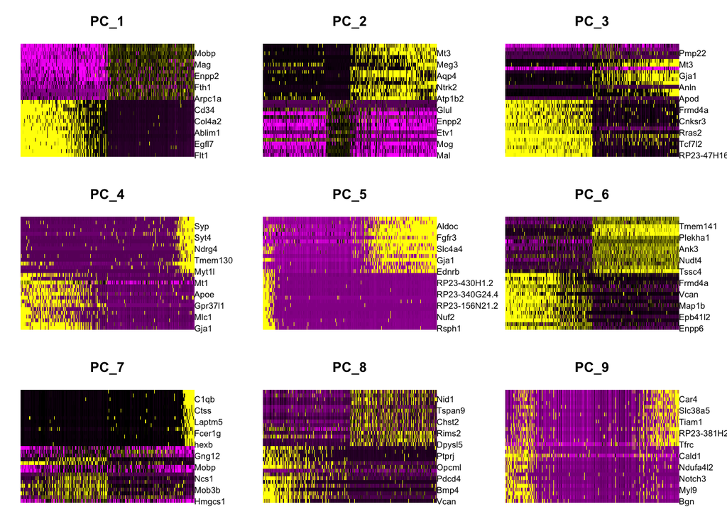

```r
DimHeatmap(socr, dims = 1:9, cells = 500, balanced = TRUE)
```

```r
# Regressing out the cell cycle:

socr_cc <- CellCycleScoring(socr_norm, s.features = s.genes, g2m.features = g2m.genes, set.ident = TRUE)
socr_cc <- ScaleData(socr_cc, vars.to.regress = c("S.Score", "G2M.Score"), features = rownames(socr_norm))
socr_cc <- RunPCA(socr_cc, features = VariableFeatures(object = socr_cc))
```

```
## PC_ 1
## Positive:  Flt1, Cldn5, Itm2a, Egfl7, Slco1a4, Adgrf5, Ablim1, Cd93, Ly6c1, Col4a2
##     Adgrl4, Rgs5, Cd34, Fn1, Eng, Ptprb, Itga1, Spock2, Id1, Kdr
##     Fam101b, Abcb1a, Ebf1, Slco1c1, Klf2, Col4a1, Igfbp7, Podxl, Ly6e, Ly6a
## Negative:  Cnp, Cldn11, Mobp, Mbp, Mog, Mag, Tspan2, Hmgcs1, Mal, Enpp2
##     Fth1, Dpysl2, Olig1, Ank3, Arpc1a, Tsc22d4, Sh3gl3, Etv1, Fez1, Grb14
##     Sema4d, Nfasc, Opalin, Trf, Bin1, Gsn, Marcksl1, Kndc1, Nudt4, Hapln2
## PC_ 2
## Positive:  Mal, Fth1, Mobp, Mog, Cldn11, Gng11, Etv1, Cnp, Tspan2, Enpp2
##     Mag, Ptn, Klf13, Mbp, Hapln2, Trf, Slc6a6, Hmgcs1, Glul, Anln
##     Apod, Grb14, Flt1, Gsn, Cldn5, Adgrl4, Slco1a4, Cd93, Ly6c1, Rasgrp3
## Negative:  Chchd10, Gpm6a, Mt3, Slc38a1, Id4, Gja1, Aqp4, Meg3, Nnat, Nsg2
##     Ntrk2, Tmem47, Rtn1, Atp1b2, Fut9, Mlc1, Clu, Gpr37l1, Ptprz1, Gabrb1
##     Sox9, Aldoc, Ednrb, RP23-168E14.7, Nrxn1, Slc4a4, Celf4, RP24-160I20.1, Ramp1, Marcks
## PC_ 3
## Positive:  RP23-47H16.3, RP23-95H5.1, Gpr17, Tcf7l2, Marcks, Rras2, Kank1, Nfasc, Cnksr3, Frmd4a
##     Slc1a1, Rims2, Parvb, Tmem2, Fyn, Col9a3, RP23-416H10.8, AC163993.2, Itpr2, Sirt2
##     Prom1, Pcdh7, Rnf122, Rtn1, Opcml, Tmem163, Tnr, Rasgef1b, Sez6l, Cntn1
## Negative:  Fth1, Etv1, Mal, Glul, Gja1, Mt3, Aqp4, Hapln2, Id4, Slc1a3
##     Atp1b2, Apoe, Chchd10, Tmem47, Pmp22, Slc4a4, Mlc1, Sox9, Slc1a2, Clu
##     RP24-160I20.1, Sparcl1, Slc6a11, Aldoc, Trf, Ntsr2, Gng11, Ndrg2, Apod, Anln
## PC_ 4
## Positive:  Gja1, Aqp4, Sox9, Mlc1, Nnat, RP24-160I20.1, Gpr37l1, Slc4a4, Apoe, Mt1
##     Id4, Ednrb, Ramp1, Clu, Tmem47, Rsph1, Slc6a11, Fgfr3, Dynlrb2, Mt3
##     Bcan, Prelp, Ntsr2, Atp1b2, Slc25a18, RP23-100C7.3, Sparcl1, Nuf2, Slc1a2, Acsbg1
## Negative:  Slc12a5, Celf4, Syp, Sncb, Snap25, Syt4, Nrsn2, Stmn2, Ndrg4, Scg2
##     Rian, Tmem130, Meg3, Nrsn1, Myt1l, Snhg11, RP23-35N23.2, Scn1a, Syt1, Scn2b
##     Grin2b, Clstn3, Elavl2, Kcnc1, Pgm2l1, Gap43, Gabra1, Napb, Bend6, Ina
## PC_ 5
## Positive:  Rsph1, RP23-100C7.3, Cd24a, Nuf2, Dnah12, Ccdc153, RP23-156N21.2, Dynlrb2, RP23-340G24.4, AL669896.1
##     Tmem107, Calml4, RP23-430H1.2, Rsph4a, Dnah9, RP23-81N4.4, Fam183b, Spef2, Hdc, Tm4sf1
##     Riiad1, Dnah6, Dnah5, Vwa3a, Cfap54, RP23-96I9.2, RP24-314J18.1, Fam216b, Meig1, Tmem212
## Negative:  Slc6a11, Ntsr2, Aldoc, Atp1b2, Slc1a2, Atp1a2, Fgfr3, RP23-168E14.7, Slc4a4, Aqp4
##     Gjb6, Gja1, Acsbg1, Acsl6, Ednrb, Agt, Gpm6a, Sparcl1, Ptprz1, Fut9
##     Slc39a12, Id2, S1pr1, Itih3, Ncan, Apoe, Cxcl14, Gpr37l1, Htra1, Gfap
```

```r
print(socr_cc[["pca"]], dims = 1:5, nfeatures = 5)
```

```
## PC_ 1
## Positive:  Flt1, Cldn5, Itm2a, Egfl7, Slco1a4
## Negative:  Cnp, Cldn11, Mobp, Mbp, Mog
## PC_ 2
## Positive:  Mal, Fth1, Mobp, Mog, Cldn11
## Negative:  Chchd10, Gpm6a, Mt3, Slc38a1, Id4
## PC_ 3
## Positive:  RP23-47H16.3, RP23-95H5.1, Gpr17, Tcf7l2, Marcks
## Negative:  Fth1, Etv1, Mal, Glul, Gja1
## PC_ 4
## Positive:  Gja1, Aqp4, Sox9, Mlc1, Nnat
## Negative:  Slc12a5, Celf4, Syp, Sncb, Snap25
## PC_ 5
## Positive:  Rsph1, RP23-100C7.3, Cd24a, Nuf2, Dnah12
## Negative:  Slc6a11, Ntsr2, Aldoc, Atp1b2, Slc1a2
```

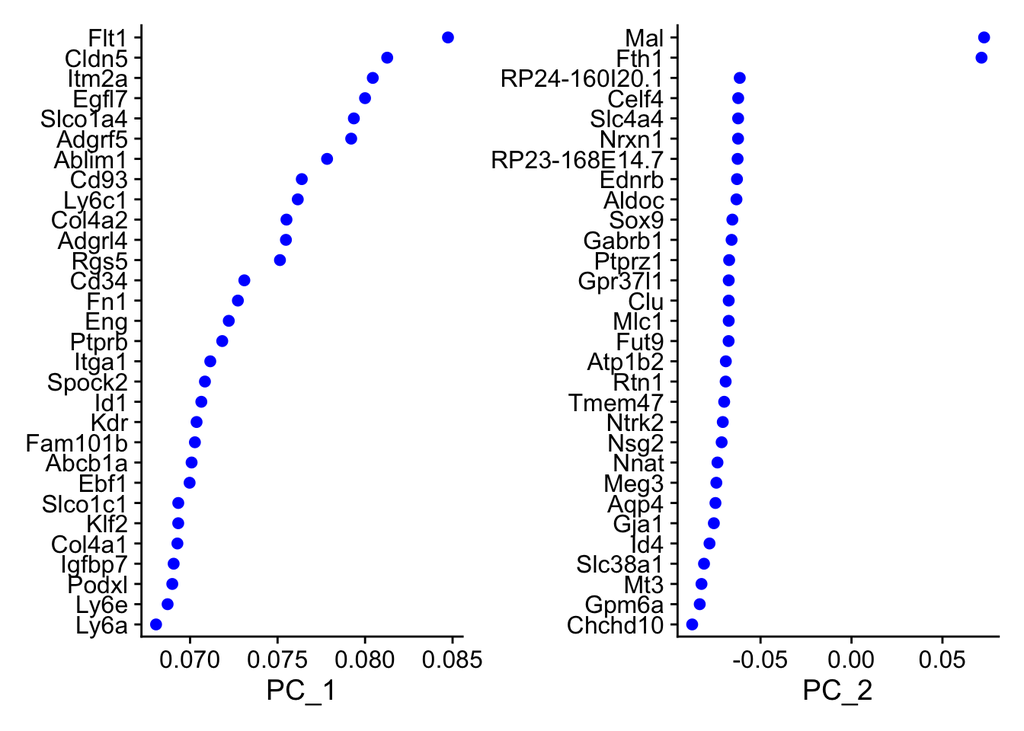

```r
VizDimLoadings(socr_cc, dims = 1:2, reduction = "pca")
```

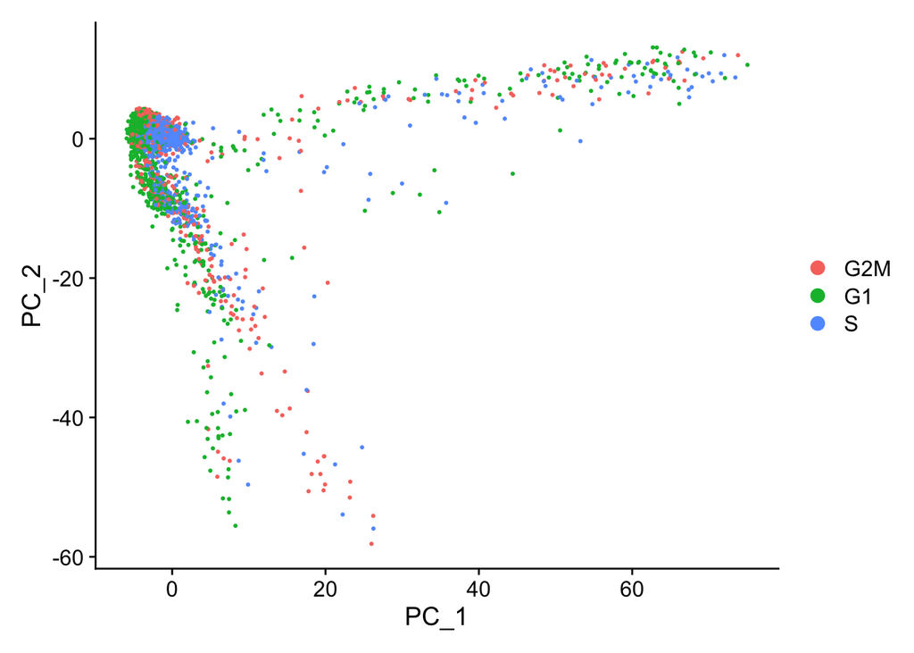

```r
DimPlot(socr_cc, reduction = "pca")
```

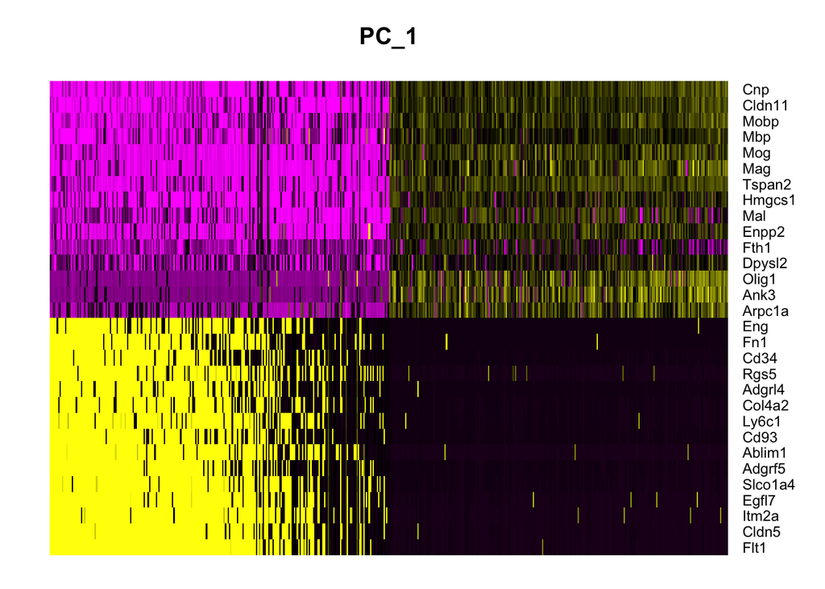

```r
DimHeatmap(socr_cc, dims = 1, cells = 500, balanced = TRUE)
```

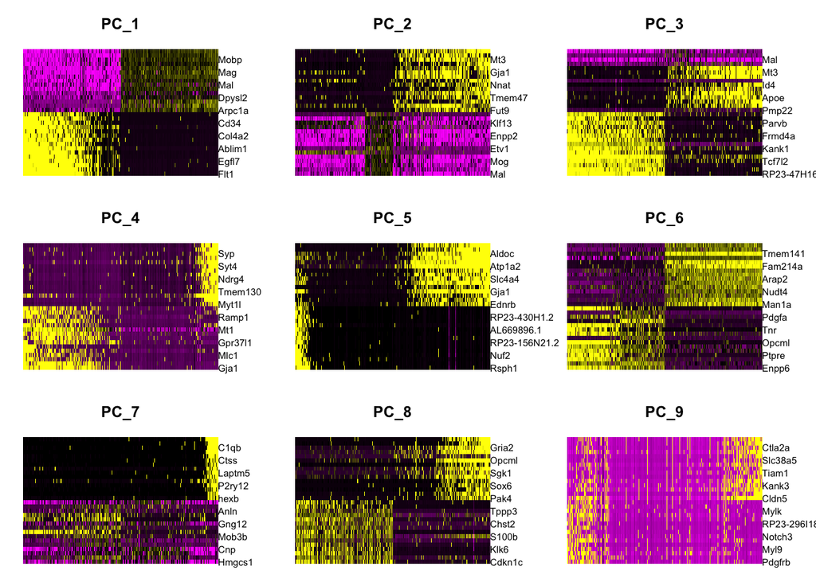

```r
DimHeatmap(socr_cc, dims = 1:9, cells = 500, balanced = TRUE)
```

Question 8:

After computing the PCA on the 2,000 most variable genes, produce the elbow plot and insert the corresponding Figure here. How many dimensions are you going to choose for subsequent analyses?

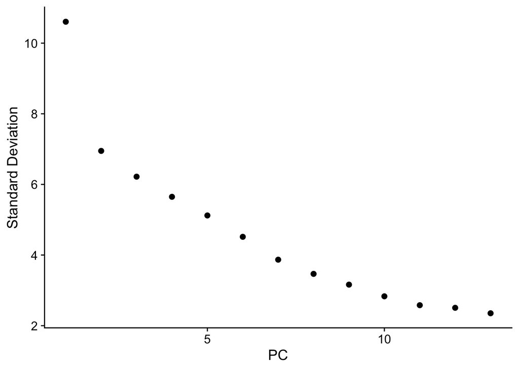

```r
ElbowPlot(socr_cc, ndims=13)
```

```r
# Determine percent of variation associated with each PC
pct <- socr_cc[["pca"]]@stdev / sum(socr_cc[["pca"]]@stdev) * 100

# Calculate cumulative percents for each PC
cumu <- cumsum(pct)

# Determine which PC exhibits cumulative percent greater than 90% and % variation associated with the PC as less than 5
co1 <- which(cumu > 90 & pct < 5)[1]
co1
```

```
## [1] 42
```

```r
# Determine the difference between variation of PC and subsequent PC
co2 <- sort(which((pct[1:length(pct) - 1] - pct[2:length(pct)]) > 0.1), decreasing = T)[1] + 1
# last point where change of % of variation is more than 0.1%.
co2
```

```
## [1] 13
```

```r
# Minimum of the two calculation
pcs <- min(co1, co2)
pcs
```

```
## [1] 13
```

I Choose 13 as the the setting for reducing dimensions

```r
socr_cc_13 <- FindNeighbors(socr_cc, dims = 1:13)
socr_cc_13_05 <- FindClusters(socr_cc_13, resolution = 0.5)
```

```
## Modularity Optimizer version 1.3.0 by Ludo Waltman and Nees Jan van Eck
##
## Number of nodes: 5289
## Number of edges: 174077
##
## Running Louvain algorithm...
## Maximum modularity in 10 random starts: 0.8537
## Number of communities: 14
## Elapsed time: 0 seconds
```

```r
table(Idents(socr_cc_13_05))
```

```
##
##    0    1    2    3    4    5    6    7    8    9   10   11   12   13
## 1078  900  722  600  593  274  252  251  224  196   76   57   33   33
```

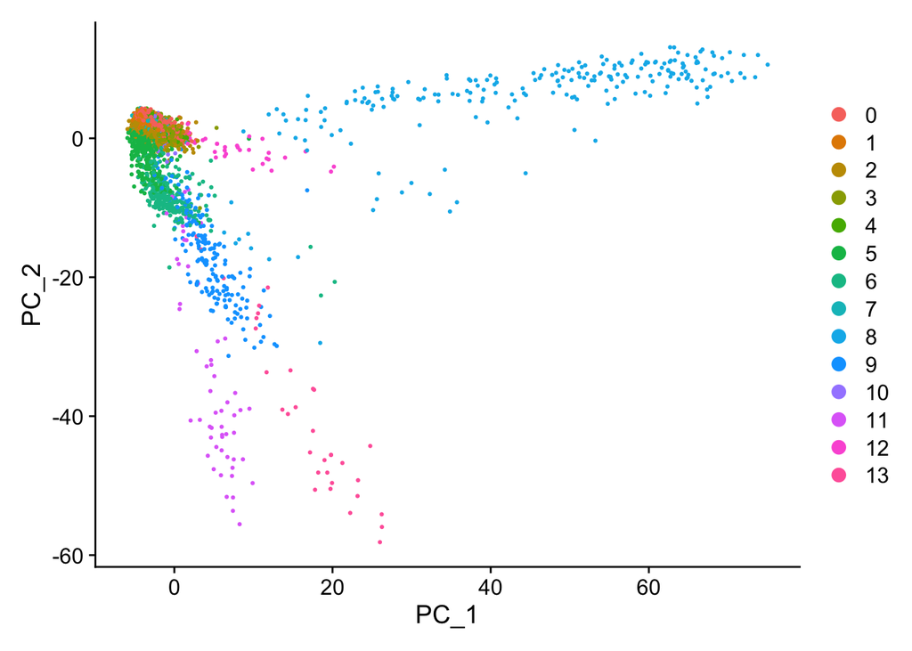

```r
#Now the PCA plot is labeled with clusters:

DimPlot(socr_cc_13_05, reduction = "pca")
```

```r
socr_cc_13_05 <- RunUMAP(socr_cc_13_05, dims = 1:13)
```

Question 9:

How many clusters do you obtain if you employ the same clustering parameters of the vignette? Insert here a table with for each cluster (identified by number) you report the number of cells belonging to it, and the Figure generated by the UMAP projection, together with the points colored by cluster.

```r
# table of cell numbers per cluster
table(socr_cc_13_05@active.ident)
```

```
##
##    0    1    2    3    4    5    6    7    8    9   10   11   12   13
## 1078  900  722  600  593  274  252  251  224  196   76   57   33   33
```

```r
socr_cc_13_05 <- RunUMAP(socr_cc_13_05, dims = 1:13)
```

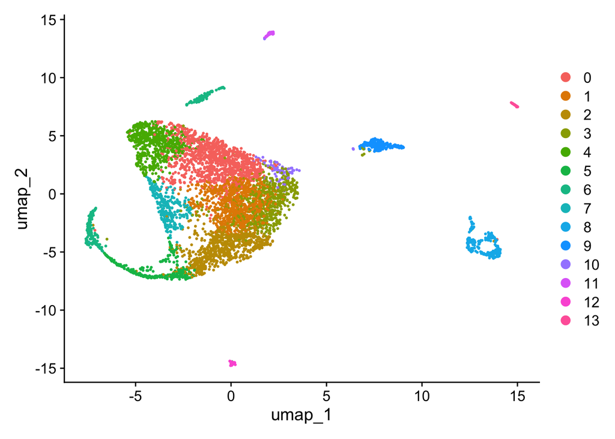

```r
DimPlot(socr_cc_13_05, reduction = "umap")
```

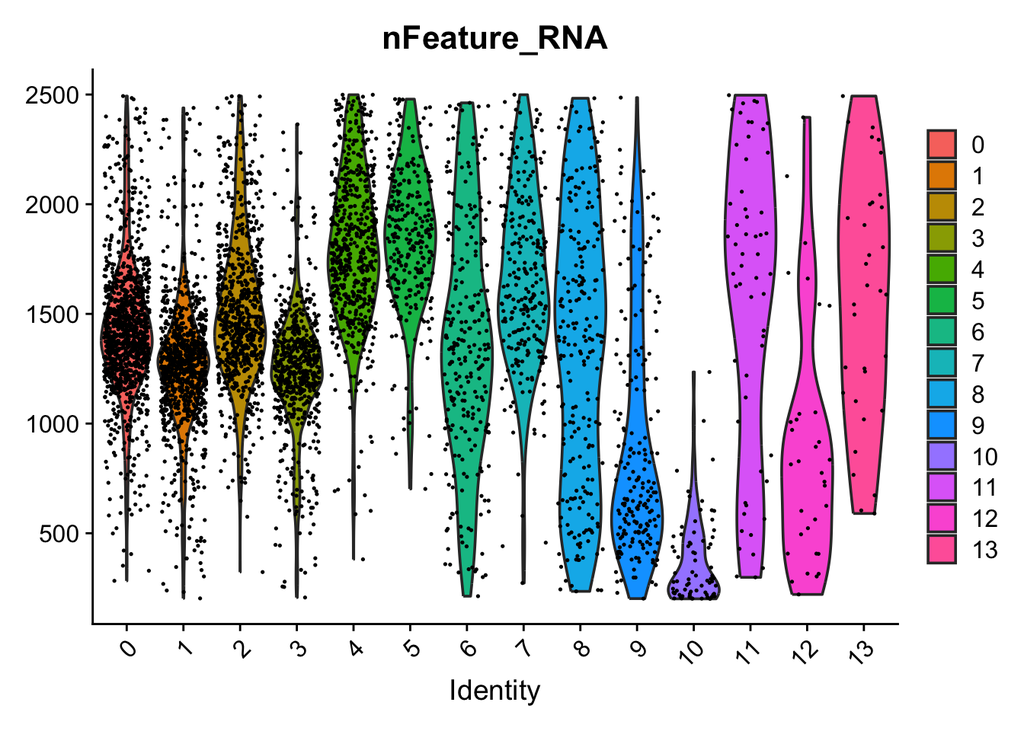

```r
VlnPlot(socr_cc_13_05, features="nFeature_RNA")
```

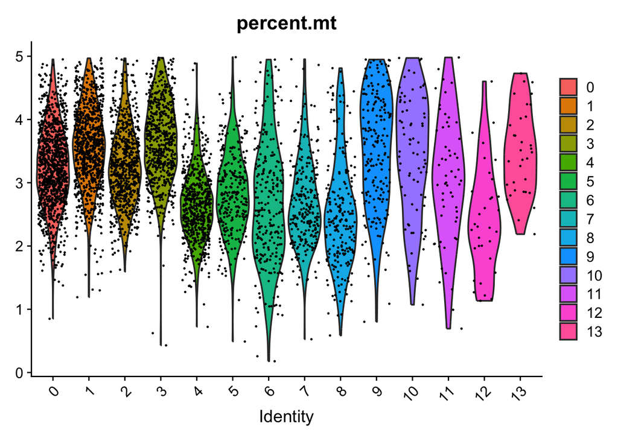

```r
VlnPlot(socr_cc_13_05, features="percent.mt")
```

Questions 10:

Identify the marker genes for each cluster, and try to assign a cell type to each cluster. Beware that finding MT genes as markers is an indicator that you have to regress out the mitochondrial RNA too.

```r
socr_cc_13_05_markers <- FindAllMarkers(socr_cc_13_05, only.pos = TRUE, min.pct = 0.25, logfc.threshold = 0.25)
```

[output not shown]

```r
markers10<-socr_cc_13_05_markers %>%
    group_by(cluster) %>%
    slice_max(n = 10, order_by = avg_log2FC)
markers10
```

```
## # A tibble: 140 × 7
## # Groups:   cluster [14]
##        p_val avg_log2FC pct.1 pct.2 p_val_adj cluster gene
##        <dbl>      <dbl> <dbl> <dbl>     <dbl> <fct>   <chr>
##  1 2.73e-198       1.55 0.813 0.311 6.22e-194 0       Pmp22
##  2 1.23e-174       1.28 0.897 0.438 2.79e-170 0       Hapln2
##  3 1.58e-117       1.20 0.747 0.374 3.60e-113 0       Anln
##  4 1.61e- 42       1.20 0.342 0.163 3.67e- 38 0       Plin3
##  5 1.45e-109       1.17 0.738 0.393 3.31e-105 0       Slco3a1
##  6 1.48e- 99       1.17 0.682 0.333 3.38e- 95 0       Spock3
##  7 2.03e-169       1.13 0.956 0.631 4.62e-165 0       Etv1
##  8 7.63e- 30       1.12 0.263 0.127 1.73e- 25 0       Myo1e
##  9 2.34e- 34       1.01 0.34  0.173 5.32e- 30 0       Rftn1
## 10 1.28e- 42       1.00 0.446 0.239 2.90e- 38 0       RP23-142A14.3
## # ℹ 130 more rows
```

Assessing cell types onto the clusters with resolution = 0.5:

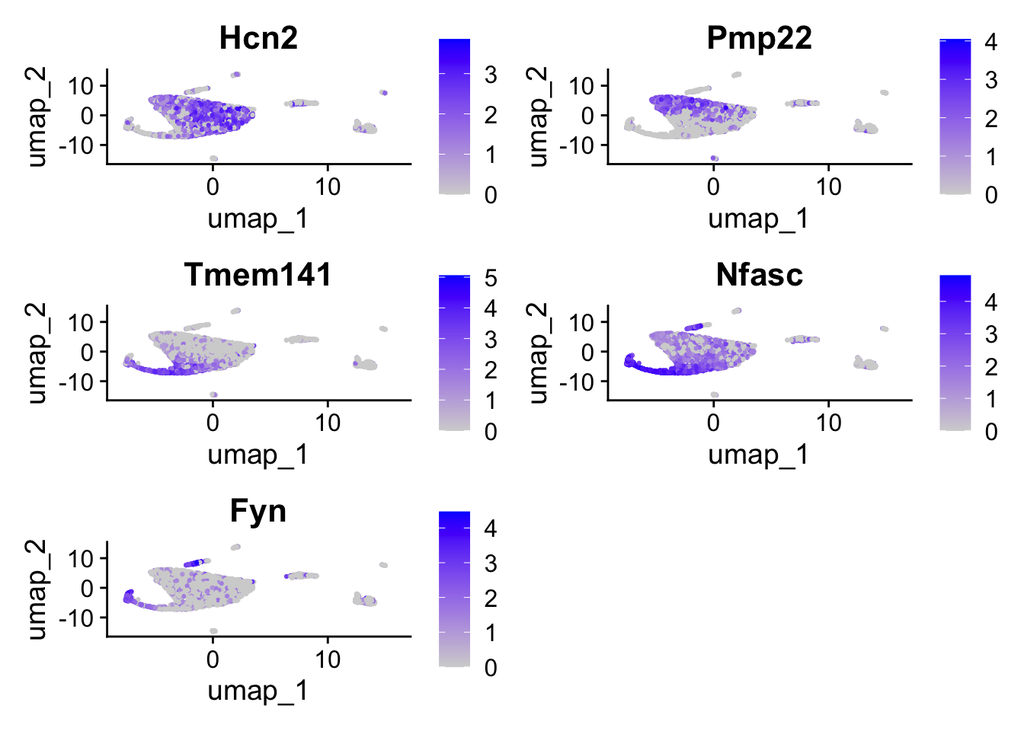

```r
FeaturePlot(socr_cc_13_05, features = c("Hcn2", "Pmp22", "Hcn2", "Tmem141", "Tmem141", "Nfasc", "Fyn"))
```

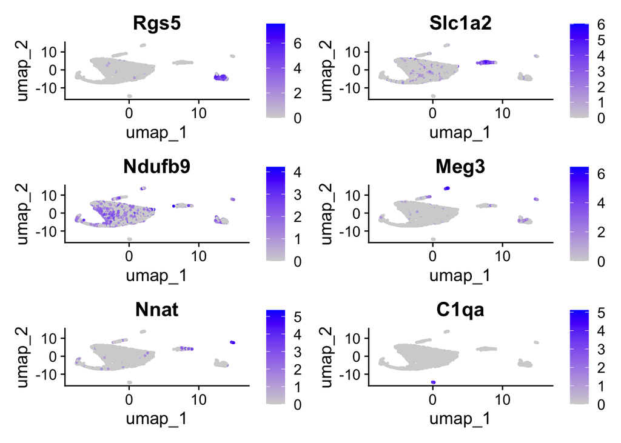

```r
FeaturePlot(socr_cc_13_05, features = c("Rgs5", "Slc1a2",   "Ndufb9", "Meg3", "Nnat", "C1qa"))
```